# Sporosphere bacteria

# Sequencing stats

Sequencing yielded 27069786 total raw sequences for the entire study, with a per-sample mean of 106156 and std. dev. of 124214.

# QC pipeline

Quality control included fastq filtration with DADA2 (maxEE=c(2,2), truncQ=2), and *de novo* chimera removal.

Read counts at each step:

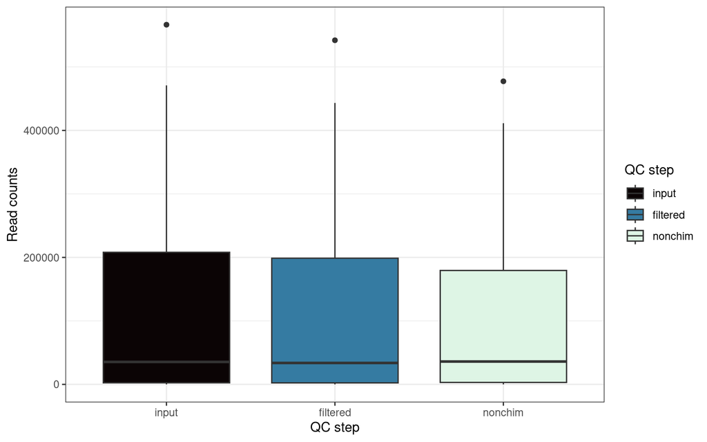

Potential contaminant ASVs were detected via the prevalence method in *decontam* by comparing each sample against a series of negative controls:

| sample_id | notes |
| --- | --- |
| SB137 | Negative spore extraction |
| SB177 | Ambient lab overnight PM - leaving a powerbead tube open overnight in spEx lab then treating like normal |
| SB199 | Lab counter swab |
| SB208 | Empty DNA kit extraction PM - left powerbead tube open to ambient DNA extr. lab conditions for ten minutes |
| SB223 | Negative spore extraction (replicate from above) |
| SB243 | Ambient lab overnight (replicate from above) PM - leaving a powerbead tube open overnight in spEx lab then treating like normal |
| SB244 | Lab counter swab |
| SB251 | Empty DNA kit extraction PM - left powerbead tube open to ambient DNA extr. lab conditions for ten minutes |

After QC screening, including the removal of likely contaminant ASVs, 8 further samples were removed due to having no remaining reads.

|  | sample_id | isolate | g_spp | treatment |
| --- | --- | --- | --- | --- |
| SB24 | SB24 | NC104B-26 | A_trappei | sterile |
| SB78 | SB78 | VA103A-24 | Ra_verrucosa | sterile |
| SB80 | SB80 | VA103A-24 | Ra_verrucosa | invam_bulk_soil |
| SB87 | SB87 | NC302C-12 | F_mosseae | invam_bulk_soil |
| SB120 | SB120 | FL979A-12 | R_clarus | unsterile |
| SB173 | SB173 | NE202-29 | Sg_constrictum | unsterile |
| SB178 | SB178 | 20_SSU | NA | NEON |
| SB193 | SB193 | 088-2-22_SSU | NA | NEON |

# Taxonomic assignment

The Silva nr99 database (v138.2) was used to assign taxonomy with *dada2::assign_taxonomy()* using a bootstrap cutoff of 70%. Species-level designations were only assigned when there was a 100% match with reference taxa across the entire amplicon.

Any taxa that matched to mitochondrial or chloroplast references were removed from all downstream analyses.

# Microbiome seqgregation

## Removal of bulk soil taxa

To separate out the “endo-sporic” and “ecto-sporic” microbiome components, we first removed taxa from each isolate that were found in similar or lesser relative abundances compared the bulk substrate from INVAM. This is a highly conservative measure, given that some valid members of the sporoshpere microbiome may *also* be present in the builk soil substrate. But it allows us to have greater confidence that the taxa we find in and on spores are truly present there and not resulting from bulk soil contamination.

The INVAM samples varied widely in the total number of reads:

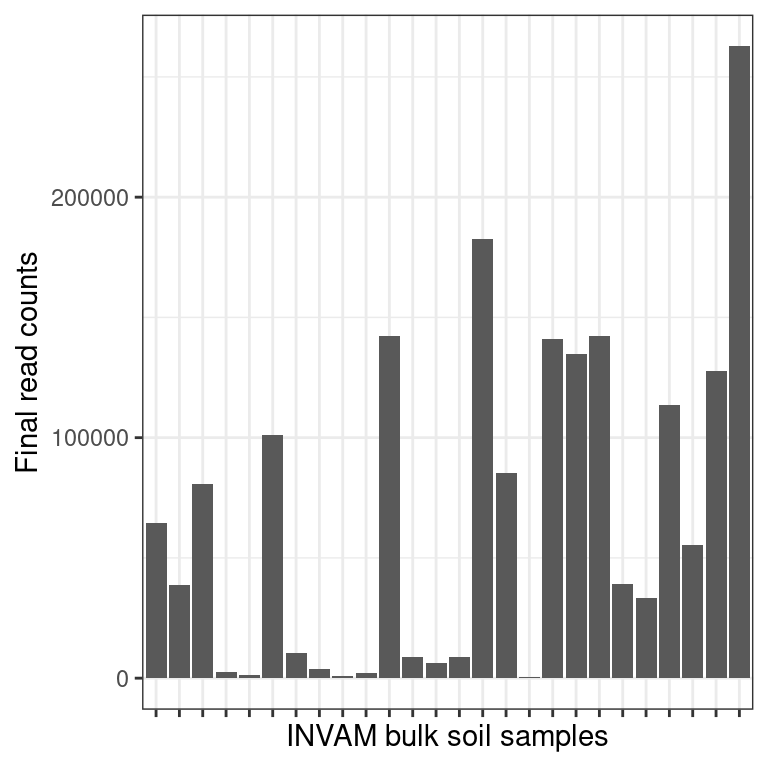

To identify the ectosporic microbiome, we then removed taxa from the unsterilized treatments that were also found in the surface-sterilized treatments from the same isolate. This is, again, a rather conservative step given that some endosporic taxa may also be genuine ectosporic community members. However, this allows us to speak confidently about the community found associated with the surface of spores without any potential carryover from endosporic taxa.

This plot shows Phylum composition for each spore isolate from INVAM. Left bars are endosporic communities, and right bars are the unsterilized, ectosporic, communities (where paired endosporic taxa have been removed).

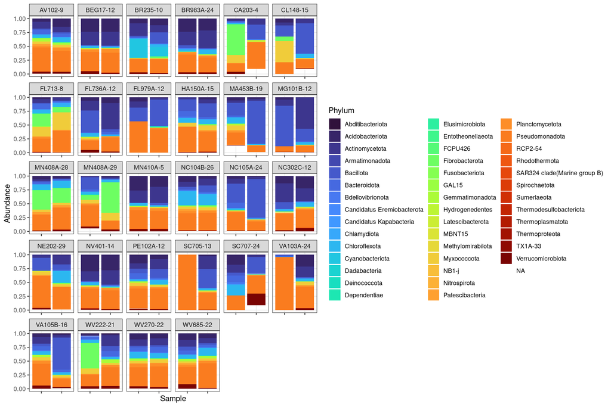

Location (endosporic vs ectosporic) did not, by itself, have significant explanatory power for community structure. However, bacterial communities varied for each isolate, and within each isolate, location was an important predictor, explaining 16.0019639% of between-sample community dissimilarity.

PermANOVA conducted with *adonis2()*:

| term | df | SumOfSqs | R2 | statistic | p.value |
| --- | --- | --- | --- | --- | --- |
| isolate | 27 | 22.7356136 | 0.3123035 | 2.1906217 | 0.001 |
| treatment | 1 | 0.3598327 | 0.0049428 | 0.9361063 | 0.569 |
| isolate:treatment | 27 | 11.6493894 | 0.1600196 | 1.1224419 | 0.001 |
| Residual | 99 | 38.0549122 | 0.5227341 | NA | NA |
| Total | 154 | 72.7997479 | 1.0000000 | NA | NA |

# Definition of “core microbiome”

Just looking at the number of core taxa across isolates (not identity or composition), no AMF traits other than shape had any significant effect on endosporic core microbiome richness. However, all observed traits had significant effects on ectosporic (total) core microbiome richness:

| term | estimate | std.error | statistic | p.value | location |
| --- | --- | --- | --- | --- | --- |
| (Intercept) | -225.7299 | 37.9910 | -5.9417 | 0.0272 | Ectosporic (total) |
| trait_orn_height_mean | 16.1910 | 2.0419 | 7.9294 | 0.0155 | Ectosporic (total) |
| trait_color_most | -60.4515 | 5.4541 | -11.0836 | 0.0080 | Ectosporic (total) |
| trait_vol_mean | 0.0000 | 0.0000 | 9.7674 | 0.0103 | Ectosporic (total) |
| trait_shape_median | 619.9480 | 68.5860 | 9.0390 | 0.0120 | Ectosporic (total) |
| trait_investment_mean | -515.0121 | 42.6406 | -12.0780 | 0.0068 | Ectosporic (total) |
| (Intercept) | -135.8730 | 151.0418 | -0.8996 | 0.4346 | Endosporic |
| trait_orn_height_mean | -76.6682 | 39.6560 | -1.9333 | 0.1487 | Endosporic |
| trait_color_most | -15.3303 | 11.3840 | -1.3467 | 0.2708 | Endosporic |
| trait_vol_mean | 0.0000 | 0.0000 | 2.0144 | 0.1374 | Endosporic |
| trait_shape_median | -277.8523 | 62.6782 | -4.4330 | 0.0213 | Endosporic |
| trait_investment_mean | 1336.5778 | 750.5677 | 1.7808 | 0.1730 | Endosporic |

Here’s a look at the core endosporic microbiome taxa across AMF species:

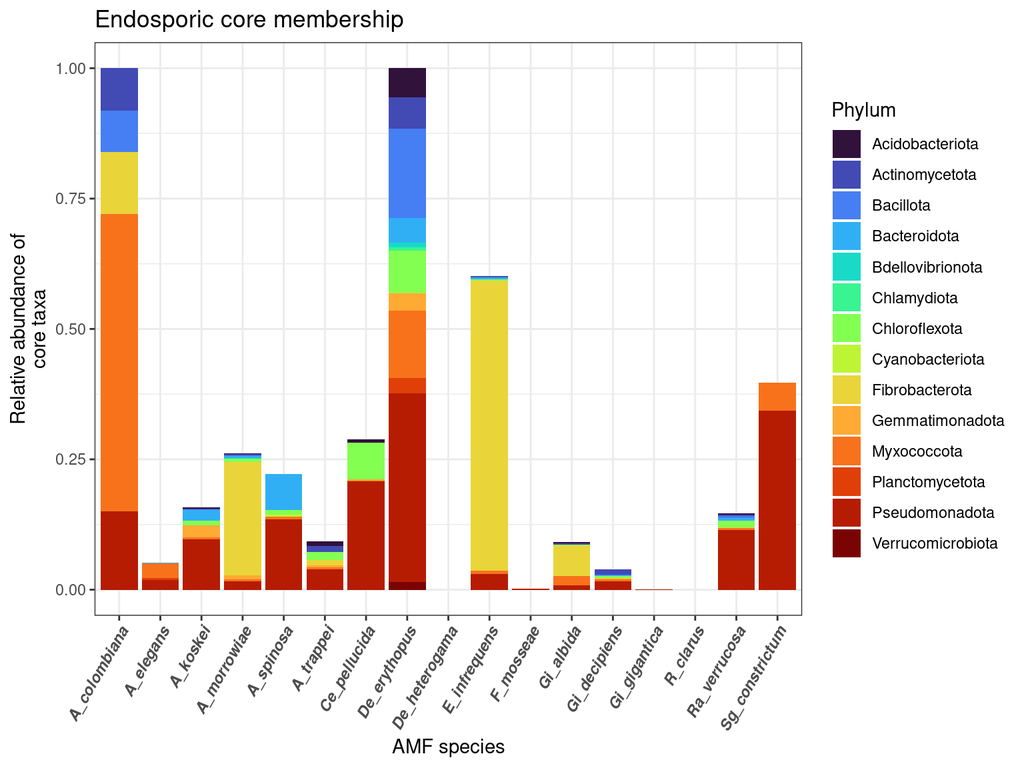